# FigureYa4 bestSeparation

# Academic Citation

If you use this code in your work or research, we kindly request that you cite our publication:

Xiaofan Lu, et al. (2025). FigureYa: A Standardized Visualization Framework for Enhancing Biomedical Data Interpretation and Research Efficiency. iMetaMed. https://doi.org/10.1002/imm3.70005

## 需求描述

## Requirement description

做生存分析，Best separation和Median separation，后者很简单，很想学前者，求Best separation的代码

Do survival analysis, Best separation and Median separation. The latter is very simple. If you really want to learn the former, look for the code for Best separation.

## 使用场景

## Usage scenario

在展示基因表达水平（连续变量）对生存期的影响时找到最佳分组

Find the best grouping when showing the impact of gene expression level (continuous variables) on survival

## 输入

## Input

包含基因表达水平、生存时间、追踪情况等三列的文件，测试用文件为dsg1.txt

A file containing three columns of gene expression levels, survival time, and tracking, the file used for testing is dsg1.txt

```r
source("install_dependencies.R")
```

```
## Starting R package installation...
## ===========================================
##
## Installing CRAN packages...
## Package already installed: ggplot2
## Package already installed: survival
## Package already installed: survminer
##
## ===========================================
## Package installation completed!
## You can now run your R scripts in this directory.
```

```r
library(survival)
library("survminer")
library(ggplot2)

#读入测试文件dsg1.txt
#read the test file dsg1.txt
svdata<-read.table("dsg1.txt",header=T,as.is=T)
head(svdata)
```

```
##   expression futime fustat
## 1     6.6980   1100      0
## 2     6.5767   1835      0
## 3     8.2342   2393      1
## 4     6.6820   1212      0
## 5     6.6826    987      1
## 6     9.2435   1939      1
```

```r
#对行按照基因表达水平排序，默认从低到高
#Sort the rows by gene expression levels, with the default order being from low to high
sortsv<-svdata[order(svdata$expression),]
```

## 输出

## Output

中位值分组的生存曲线、最佳分组生存曲线、遍历所有分组情况下的P值和Hazard Ratio的分布情况

The survival curve of the median value group, the best group survival curve, and the distribution of P value and Hazard Ratio in all grouping situations

## 中位值分组

## Median separation

```r
#先根据表达水平的中位值分组，画生存曲线，保存
#First, group according to the median separation of the expression level, draw a survival curve, and save
ssdf<-cbind(sortsv,data.frame(gp=ifelse(sortsv$expression>median(sortsv$expression),"high","low")))
fit<-survfit(Surv(futime,fustat)~gp,data=ssdf)
pdf(file="medianSeparation.pdf")
sc_median<-ggsurvplot(fit, linetype = "strata", conf.int = F, pval = TRUE,palette = c("#D95F02","#1B9E77"),legend.title="",legend=c(0.7,0.9),legend.labs=c("High-expression","low-expression"))
sc_median
dev.off()
```

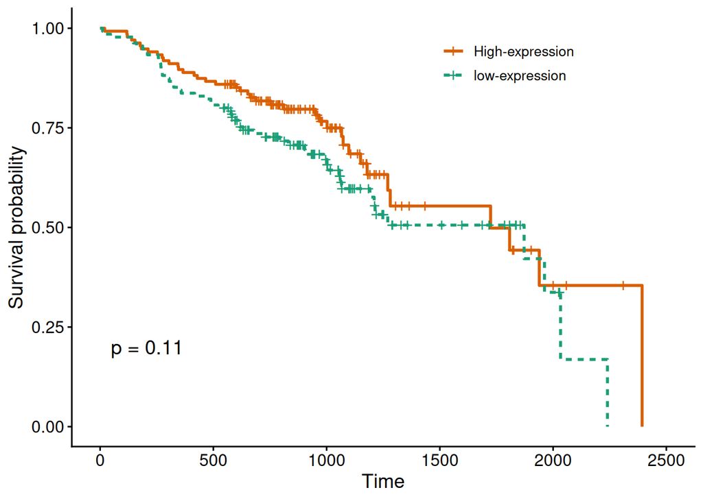

```r
sc_median
```

遍历所有分组情况，计算P值和Hazard Ratio，p值用于判断分组之间差异是否显著，而Hazard Ratio用于衡量分组之间的差异程度

Traverse all groups and calculate the P value and Hazard Ratio. The p value is used to determine whether the difference between groups is significant, while the Hazard Ratio is used to measure the degree of difference between groups.

```r
pvals<-c()
hrs<-c()
for(n in 1:(nrow(sortsv)-1)){
ssdf<-cbind(sortsv,data.frame(gp=rep(c("low","high"),c(n,nrow(sortsv)-n))))
diff<-survdiff(Surv(futime,fustat)~gp,data=ssdf,rho = 0)
pv<-pchisq(diff$chisq,length(diff$n)-1,lower.tail=FALSE)
pvals<-c(pvals,pv)
hr<-diff$obs[1]*diff$exp[2]/(diff$obs[2]*diff$exp[1])
hrs<-c(hrs,hr)
}
```

```r
fd<-data.frame(Tag=1:(nrow(sortsv)-1),HR=hrs,Pvalue=pvals)
head(fd)
```

```
##   Tag        HR     Pvalue
## 1   1 0.2912112 0.19105049
## 2   2 0.6424631 0.65680193
## 3   3 0.3579073 0.13259234
## 4   4 0.3352756 0.04992592
## 5   5 0.4226479 0.12917044
## 6   6 0.3314383 0.02266261
```

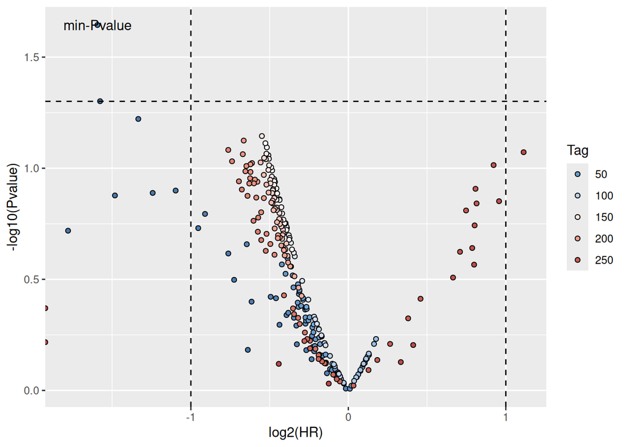

```r
ggplot(fd,aes(x=log2(HR),y=-log10(Pvalue)))+geom_point(shape=21,aes(fill=Tag))+scale_fill_gradientn(colours=c("#4477AA","#77AADD","#FFFFFF","#EE9988","#BB4444"),guide="legend")+geom_hline(yintercept=(-log10(0.05)),linetype="dashed")+geom_vline(xintercept=c(-1,1),linetype="dashed")+annotate("text",y=-log10(pvals[which.min(pvals)]),x=log2(hrs[which.min(pvals)]),label="min-Pvalue")
```

```r
ggsave(file="Pvalue_Hazard-Ratio.pdf")
```

## 最佳分组

## Best separation

虚线左上角区域的点p值最小，是最佳的分组方式，分组情况如下

The point in the upper left region of the dashed line has the smallest p-value, which is the best grouping method. The grouping situation is as follows

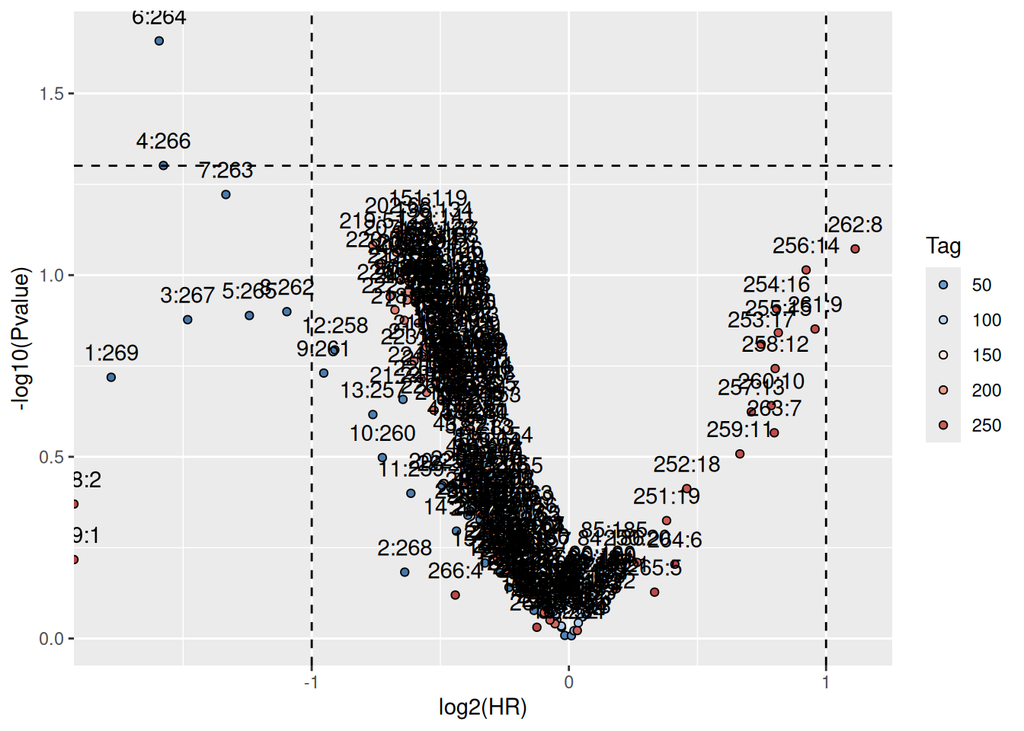

```r
ggplot(fd,aes(x=log2(HR),y=-log10(Pvalue)))+geom_point(shape=21,aes(fill=Tag))+scale_fill_gradientn(colours=c("#4477AA","#77AADD","#FFFFFF","#EE9988","#BB4444"),guide="legend")+geom_hline(yintercept=(-log10(0.05)),linetype="dashed")+geom_vline(xintercept=c(-1,1),linetype="dashed")+geom_text(aes(label=paste(Tag,nrow(sortsv)-Tag,sep=":")),vjust=-1)
```

画出最佳分组的生存曲线

Draw the survival curves of the best grouping

```r
ssdf<-cbind(sortsv,data.frame(gp=rep(c("low","high"),c(which.min(pvals),nrow(sortsv)-which.min(pvals)))))
fit<-survfit(Surv(futime,fustat)~gp,data=ssdf)
pdf(file="bestSeparation.pdf")
sc_minp<-ggsurvplot(fit, linetype = "strata", conf.int = F, pval = TRUE,palette = c("#D95F02","#1B9E77"),legend.title="",legend=c(0.7,0.9),legend.labs=c("High-expression","low-expression"))
sc_minp
dev.off()
```

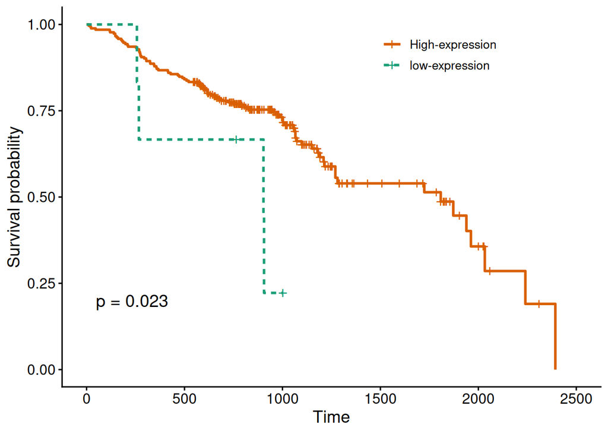

```r
sc_minp
```